# Predicción de Churn con Redes Neuronales

Proyecto Ciencia de Datos 1 | Telco Customer Churn

Alonso Untiveros

29/05/2026

Predicción de Churn con Redes Neuronales

El presente informe desarrolla un modelo predictivo para estimar la probabilidad de abandono de clientes (churn) utilizando el dataset Telco Customer Churn. Se implementaron redes neuronales mediante Keras y scikit-learn, además de un modelo clásico Random Forest como referencia comparativa.

El proyecto incluye análisis exploratorio, preprocesamiento, ingeniería de variables, tuning de hiperparámetros, evaluación, interpretabilidad y análisis de errores.

7043

Clientes analizados

0.852

ROC-AUC Keras Final

0.636

F1 Random Forest

848

Predicciones correctas

1. Objetivo del proyecto

   El objetivo fue construir, ajustar, interpretar y comparar modelos predictivos capaces de estimar si un cliente abandonará o no el servicio. El problema se abordó como una tarea de **clasificación binaria supervisada**, donde la variable objetivo fue **Churn**.
2. Dataset y análisis exploratorio

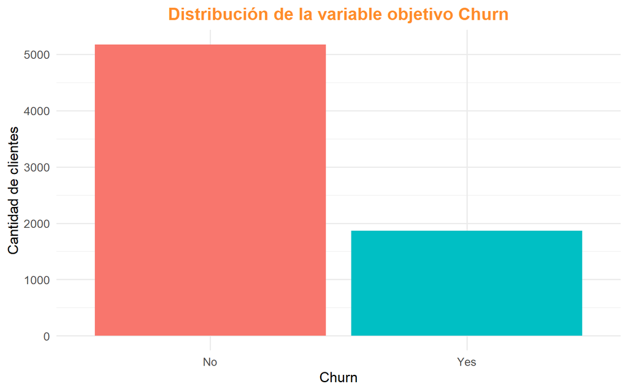

La distribución evidencia que existe una mayor cantidad de clientes que permanecen en el servicio frente a aquellos que abandonan. Esto muestra un desbalance moderado entre clases, por lo que el desempeño del modelo no debe evaluarse únicamente con Accuracy. En este contexto, métricas como F1-score, ROC-AUC y PR-AUC permiten analizar mejor la capacidad para detectar clientes con riesgo de churn.

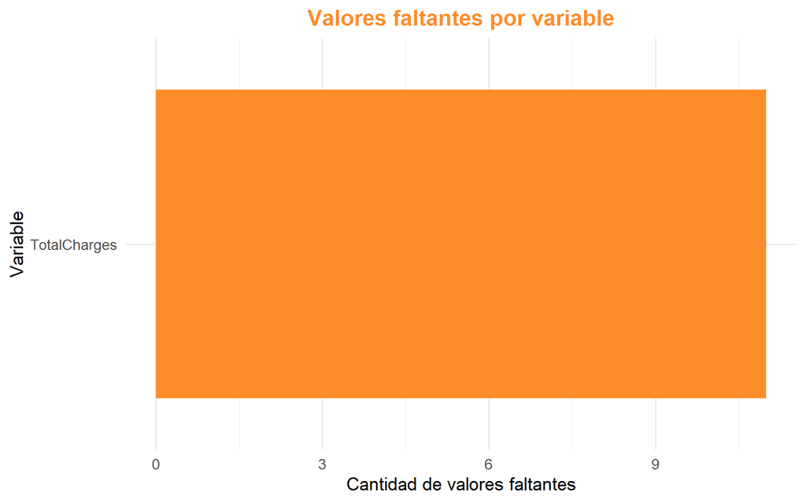

El análisis de valores faltantes muestra que la variable TotalCharges presenta registros vacíos luego de ser convertida a formato numérico. Estos valores fueron tratados posteriormente mediante imputación con la mediana dentro del pipeline de preprocesamiento, evitando eliminar observaciones y reduciendo pérdida de información.

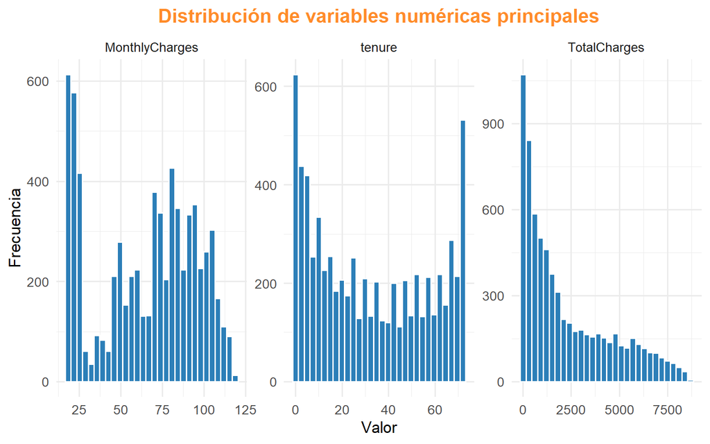

3. Preprocesamiento

El preprocesamiento incluyó tratamiento de valores perdidos, codificación de variables categóricas, escalamiento, partición train/validation/test y control de data leakage. La variable customerID fue retirada porque es un identificador único y no aporta información predictiva real.

Resumen del preprocesamiento aplicado

| Etapa | Técnica |
| --- | --- |
| Valores perdidos | Imputación con mediana/moda |
| Variables categóricas | OneHotEncoder |
| Variables numéricas | StandardScaler |
| Partición de datos | Train / Validation / Test |
| Control de leakage | Pipeline ajustado solo con entrenamiento |

El pipeline fue ajustado únicamente con los datos de entrenamiento y luego aplicado a validación y prueba. Esta práctica evita data leakage, ya que impide que información del conjunto de prueba influya en el aprendizaje del modelo.

4. Ingeniería de variables

   Se crearon cinco variables derivadas para capturar patrones de comportamiento del cliente asociados al abandono.

Promedio de variables derivadas según Churn

| Churn | cargo_promedio_mensual | cliente_nuevo | contrato_largo_plazo | cantidad_servicios | riesgo_pago_electronico_mensual |
| --- | --- | --- | --- | --- | --- |
| No | 57.780 | 0.135 | 0.571 | 3.036 | 0.165 |
| Yes | 62.683 | 0.419 | 0.114 | 2.677 | 0.532 |

Las variables derivadas permiten representar mejor patrones de riesgo. Por ejemplo, cliente nuevo permite capturar abandono temprano, contrato de largo plazo representa estabilidad contractual, cantidad de servicios contratados mide vinculación con la empresa y riesgo por pago electrónico mensual identifica un perfil potencialmente más sensible al churn.

5. Modelo Keras

   Se implementó una red neuronal tipo perceptrón multicapa usando Keras. El modelo final incluyó tuning de hiperparámetros, regularización L2, dropout, early stopping, selección de learning rate, batch size y arquitectura de capas.

Resultados del modelo Keras final

| Modelo | Accuracy | F1_score | ROC_AUC | PR_AUC |
| --- | --- | --- | --- | --- |
| Keras Final | 0.802 | 0.596 | 0.852 | 0.666 |

El modelo Keras Final obtuvo Accuracy = 0.802, F1-score = 0.596, ROC-AUC = 0.852 y PR-AUC = 0.666. El ROC-AUC indica una buena capacidad para diferenciar clientes que abandonan de aquellos que permanecen.

[figure not shown]

6. Modelo scikit-learn

   Como segunda librería se utilizó scikit-learn mediante MLPClassifier, una red neuronal tipo perceptrón multicapa. Esto permitió comparar dos implementaciones de redes neuronales sobre el mismo conjunto de datos procesado.

Resultados del modelo MLP scikit-learn

| Modelo | Accuracy | F1_score | ROC_AUC | PR_AUC |
| --- | --- | --- | --- | --- |
| MLP scikit-learn | 0.796 | 0.524 | 0.85 | 0.663 |

El modelo MLP de scikit-learn alcanzó un ROC-AUC = 0.850, muy cercano al modelo Keras. Sin embargo, su F1-score = 0.524 fue menor, lo cual refleja una menor capacidad para equilibrar precisión y recall en la clase churn.

7. Ablation Study y comparación de modelos

Comparación global de modelos

| Modelo | Accuracy | F1_score | ROC_AUC | PR_AUC |
| --- | --- | --- | --- | --- |
| Keras Final | 0.802 | 0.596 | 0.852 | 0.666 |
| MLP scikit-learn | 0.796 | 0.524 | 0.850 | 0.663 |
| Random Forest | 0.763 | 0.636 | 0.849 | 0.667 |

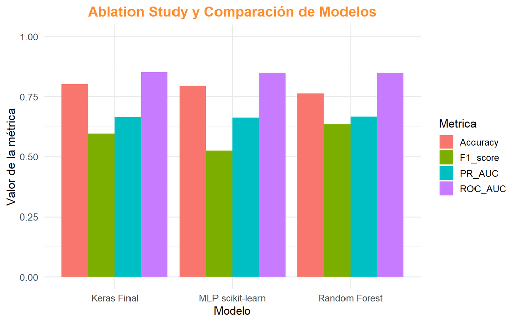

Los resultados muestran que Keras Final obtuvo el mejor desempeño global en Accuracy = 0.802 y ROC-AUC = 0.852, lo que indica una mayor capacidad general para diferenciar clientes con churn y sin churn. Por otro lado, Random Forest obtuvo el mejor F1-score = 0.636 y PR-AUC = 0.667, mostrando mejor equilibrio para detectar clientes churn.

8. Interpretabilidad

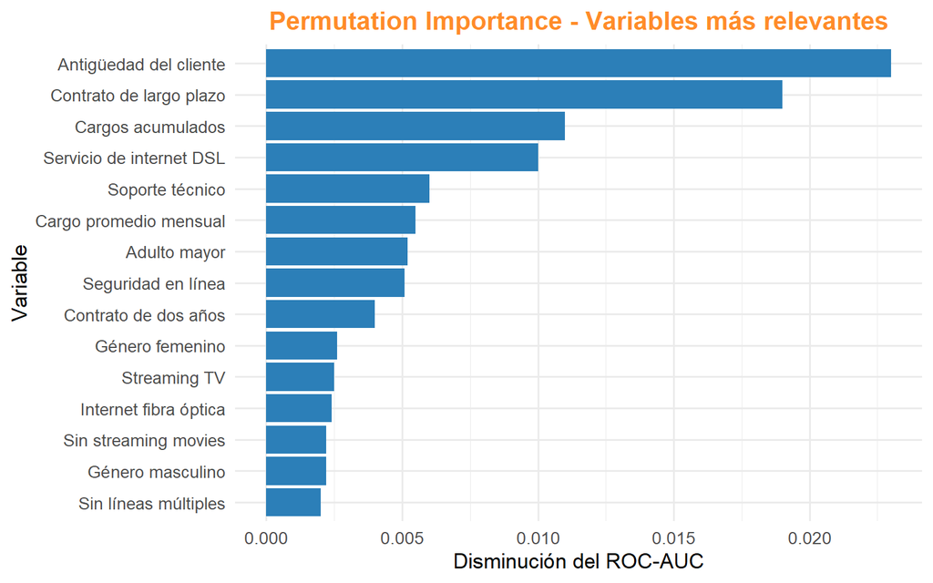

Las variables con mayor impacto fueron antigüedad del cliente y contrato de largo plazo. Al alterar la antigüedad, el ROC-AUC disminuye aproximadamente en 0.023, mientras que al alterar el contrato de largo plazo disminuye cerca de 0.019. Esto confirma que la permanencia histórica y la estabilidad contractual son factores clave para explicar el churn.

9. Análisis de errores

Resumen de errores del modelo

| Tipo | Cantidad | Probabilidad_promedio | Probabilidad_minima | Probabilidad_maxima |
| --- | --- | --- | --- | --- |
| Correcto | 848 | 0.247 | 0.005 | 0.865 |
| Falso negativo | 126 | 0.320 | 0.049 | 0.497 |
| Falso positivo | 83 | 0.604 | 0.502 | 0.824 |

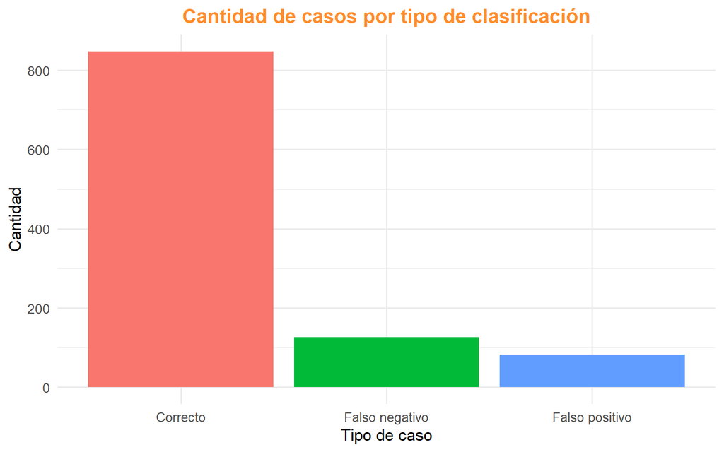

El modelo obtuvo 848 predicciones correctas, 126 falsos negativos y 83 falsos positivos. Los falsos negativos tuvieron una probabilidad promedio de churn de 0.320, lo que indica que el modelo subestimó el riesgo en ciertos clientes que sí abandonaron. Los falsos positivos presentaron una probabilidad promedio de 0.604, evidenciando sobreestimación del riesgo en algunos perfiles ambiguos.

10. Conclusión final

El proyecto permitió construir un flujo completo de ciencia de datos para predecir abandono de clientes en el dataset Telco Customer Churn. Se implementaron redes neuronales en Keras y scikit-learn, además de un modelo clásico Random Forest para comparación.

El modelo Keras Final obtuvo el mejor desempeño global, con Accuracy = 0.802, ROC-AUC = 0.852 y F1-score = 0.596, demostrando una buena capacidad para diferenciar clientes que abandonan de aquellos que permanecen.

Desde la interpretabilidad, las variables más importantes fueron la antigüedad del cliente, el tipo de contrato, los cargos acumulados, el cargo promedio mensual, el soporte técnico y los servicios contratados. Estos hallazgos son coherentes con la lógica del negocio, ya que clientes con menor antigüedad, contratos mensuales y menor vinculación suelen presentar mayor riesgo de abandono.

El análisis de errores mostró que los falsos negativos son el principal desafío del modelo, debido a que representan clientes que abandonan pero no fueron detectados oportunamente. Como mejora futura, se recomienda ajustar el umbral de clasificación, incorporar nuevas variables de comportamiento y priorizar estrategias de retención sobre clientes con probabilidades intermedias de churn.